# Homeostasis: binary, real, and multiple scales

G. Santamaria-Bonfil

# 1 Libraries required

For this notebook, the following `R` packages are required: `gdata`, `dga`, `dplyr`, and `lsa`. Also, the script `Homeostasis.R` is required.

# 2 Homeostasis and the Hamming distance

One of the most impressive abilities of many organisms is their ability to ensure a reasonably stable internal state despite wildly changing external environmental factors. This ability is often termed Homeostasis (H). More broadly, H refers to a general principle that safeguards the stability of natural and artificial systems, where stability is understood in its more classical sense of robustness against external perturbations. An interesting interpretation of H is given by the dynamical systems approach. This considers that the state of the system at any given time is defined in some state space. In it, the system homeostatic behavior is assumed to be an orbit in some attractor which represents the “optimal” condition for the system.

In accordance to (Gershenson and Fernández 2012; Fernández, Maldonado, and Gershenson 2014), H is calculated using the Hamming distance. The latter is an useful proxy for estimating H when the variables related to the state of a system $\mathbf{x}_i=[x_1^1, x_1^2,\ldots,x_1^n]$ can only take binary values, i.e., $x_i^j\in\{0,1\}$.

The Hamming distance can be defined using the Manhattan distance as follows:

$$\begin{aligned}
Ham(\mathbf{A},\mathbf{B}) &=\sum_{i=1}^n \mid a_i-b_i\mid \\
a_i,\ b_i &\in (0,1)
\end{aligned}$$
The $Ham$ distance can be normalized between $[0,1]$ by dividing it by the number of variables $n$ such as

$$Ham_n(\mathbf{A},\mathbf{B})=\frac{Ham(\mathbf{A},\mathbf{B})}{n}$$
Using this definition we can observe that, $\mathbf{A}=\mathbf{B} \implies Ham_n(\mathbf{A},\mathbf{B})=0$, $\mathbf{A}\neq \mathbf{B} \implies Ham_n(\mathbf{A},\mathbf{B})=1$, and $\mathbf{A}\ uncorrelated\ \mathbf{B} \implies Ham_n(\mathbf{A},\mathbf{B}) \approx 0.5$. In the case of binary values, the $Ham_n$ distance can be used to estimate the homeostasis ($h$) between two states $\mathbf{A}$ and $\mathbf{B}$ such as

$$h=1-Ham_n \tag{1}$$

This definition allows that $h=1$ iff $\mathbf{A}=\mathbf{B}$, $h=0$ iff $\mathbf{A}\neq\mathbf{B}$, and $h\approx0.5$ iff $\mathbf{A}$ and $\mathbf{B}$ are uncorrelated.

Furthermore, the *average rate of change* of the states of a system, measured by the Homeostasis ($H$), is given by

$$H(\mathbf{A}_t,\mathbf{A}_{t+1})= \frac{1}{m-1} \sum_{t=0}^{m-1}
h(\mathbf{A}_t,\mathbf{A}_{t+1}) \tag{2},$$
where $m$ is the number of times the system was measured.

# 3 From Binary to $\mathbb{R}$

While the $Ham_n$ function is an useful proxy for estimating H when the variables related to the state of a system take binary values, i.e., $x_i^j\in\{0,1\}$, in the case of real-valued variables, the slightest perturbation in variables values, e.g, $x_{i}^1 \sim x_{i+1}^1$, will attain an $h\neq 0$. Further, if a large portion of the variables are perturbated by a small value $\Delta$, then, $h\approx 0$ even while the system state is, practically, the same. To avoid this issue, we propose to substitute the $Ham$ distance for a more suitable distance function.

## 3.1 Cosine similarity

Given two vectors $\mathbf{A}$ and $\mathbf{B}$, the cosine similarity is represented as follows

$$Coss(\mathbf{A},\mathbf{B})= \cos(\theta)=\frac{\mathbf{A}\cdot
\mathbf{B}}{\lVert\mathbf{A} \rVert \lVert\mathbf{B} \rVert},$$

where $\theta$ is the angle between the two vectors, and $Coss(\mathbf{A},\mathbf{B})$ is the cosine of that angle between two vectors.

The $Coss$ similarity ranges from $Coss\in[-1,1]$ where $Coss(\mathbf{A},\mathbf{B})=-1$ is obtained for two opposing vectors, $Coss(\mathbf{A},\mathbf{B})=0$ for orthogonal vectors, and $Coss(\mathbf{A},\mathbf{B})=1$ for vectors in the same direction. In contrast, in positive spaces, the cosine similarity is bounded to $[0,1]$: for $\mathbf{A}\uparrow\uparrow\mathbf{B}$ then $Coss(\mathbf{A},\mathbf{B})=1$, and for $\mathbf{A}\perp\mathbf{B}$ then $Coss(\mathbf{A},\mathbf{B})=0$ (the angle between two positive vectors cannot be greater than $90^{\circ}$).

Therefore, for $\mathbb{R}^N$ spaces, $h$ is bounded to $h\in[0,1]$ by

1. First normalizing the cosine similarity such as

$$Coss_n(\mathbf{A},\mathbf{B})=\frac{Coss(\mathbf{A},\mathbf{B})-x_{min}}{x_{max}-x_{min}},$$
where $x_{max}=1$ and $x_{min}=-1$.

2. Then, since $Coss_n(\mathbf{A},\mathbf{B})\in[0,1]$, where $Coss_n=1$ if $\mathbf{A}=\mathbf{B}$, $Coss_n=0$ if $\mathbf{A} \uparrow\downarrow \mathbf{B}$ (vectors are in opposing directions), and $Coss_n=0.5$ if $\mathbf{A} \perp \mathbf{B}$ (vectors are perpendicular), then $h$ is equal to the normalized cosine similarity

$$h=Coss_n$$
If the state space is positive ($\mathbb{R}_+^N$), then, the normalizing step is skipped, and $h=Coss$. In this case, $h\in[0,1]$ where $h=0$ if the system states are perpendicular, $h=1$ for same direction states, and $0< h < 1$ otherwise.

## 3.2 Multiple Scales

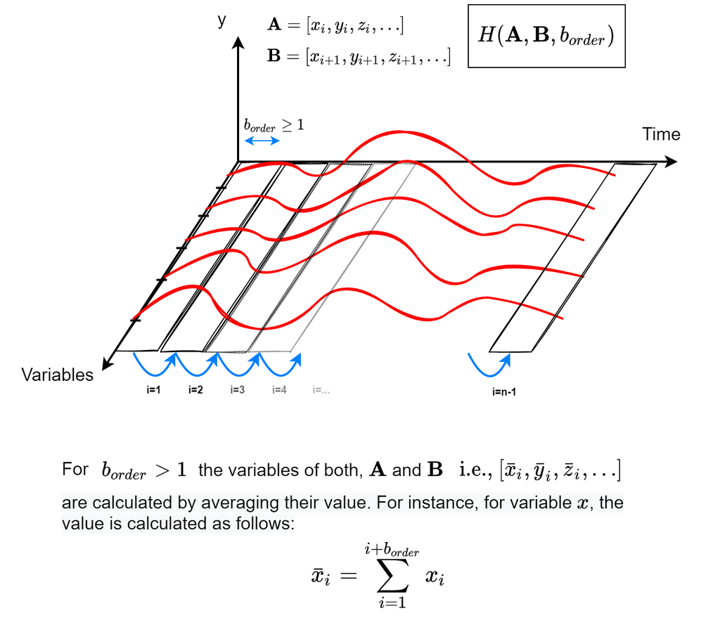

HomeostasisMultiScales

# 4 Examples

For the purpose of comparing the suitability of the distance proposals, the following examples are used:

## 4.1 Binary systems

Let us have a system with $n = 2$ variables and a seasonality of frequency 2: $11 \rightarrow 00 \rightarrow 11$. $H$ for $b_{order}=1$ will be minimal (i.e., $H=0$), since every time step all variables change, i.e. ones turn into zeros or zeros turn into ones. However, if we measure $H$ for $b_{order}=2$, then we will be actually comparing **pairs of states**, since *to make one time step in $b_{order}=2$ we take two binary time steps* (Gershenson and Fernández 2012; Fernández, Maldonado, and Gershenson 2014). Thus, the attractor becomes $1010 \rightarrow 1010$, and H = 1.

A system with n=2 variables and a seasonality of frequency 2

|  | X1 | X2 |
| --- | --- | --- |
| t_1 | 1 | 1 |
| t_2 | 0 | 0 |
| t_3 | 1 | 1 |
| t_4 | 0 | 0 |
| t_5 | 1 | 1 |
| t_6 | 0 | 0 |
| t_7 | 1 | 1 |
| t_8 | 0 | 0 |
| t_9 | 1 | 1 |
| t_10 | 0 | 0 |

A method call `homeostasis.dataframe.binary`, calculates the homeostasis of binary system states using blocks of size `b_order`. For the above example we use blocks of size $b_{order}\in \{1,\ldots,4\}$.

```r
source(homeo.lib)

tmp.hmsts.ar1 <- homeostasis.dataframe.binary(tmp.df,b_order = 1)
tmp.hmsts.ar2 <- homeostasis.dataframe.binary(tmp.df,b_order = 2)
tmp.hmsts.ar3 <- homeostasis.dataframe.binary(tmp.df,b_order = 3)
tmp.hmsts.ar4 <- homeostasis.dataframe.binary(tmp.df,b_order = 4)

tmp_res <- cbind(tmp.hmsts.ar1$H_average,tmp.hmsts.ar2$H_average,
                 tmp.hmsts.ar3$H_average,tmp.hmsts.ar4$H_average)
colnames(tmp_res) <- c('b_or=1','b_or=2','b_or=3','b_or=4')

kable(tmp_res, caption = 'Analyzing different block sizes', align='l')
```

Analyzing different block sizes

| b_or=1 | b_or=2 | b_or=3 | b_or=4 |
| --- | --- | --- | --- |
| 0 | 1 | 0 | 1 |

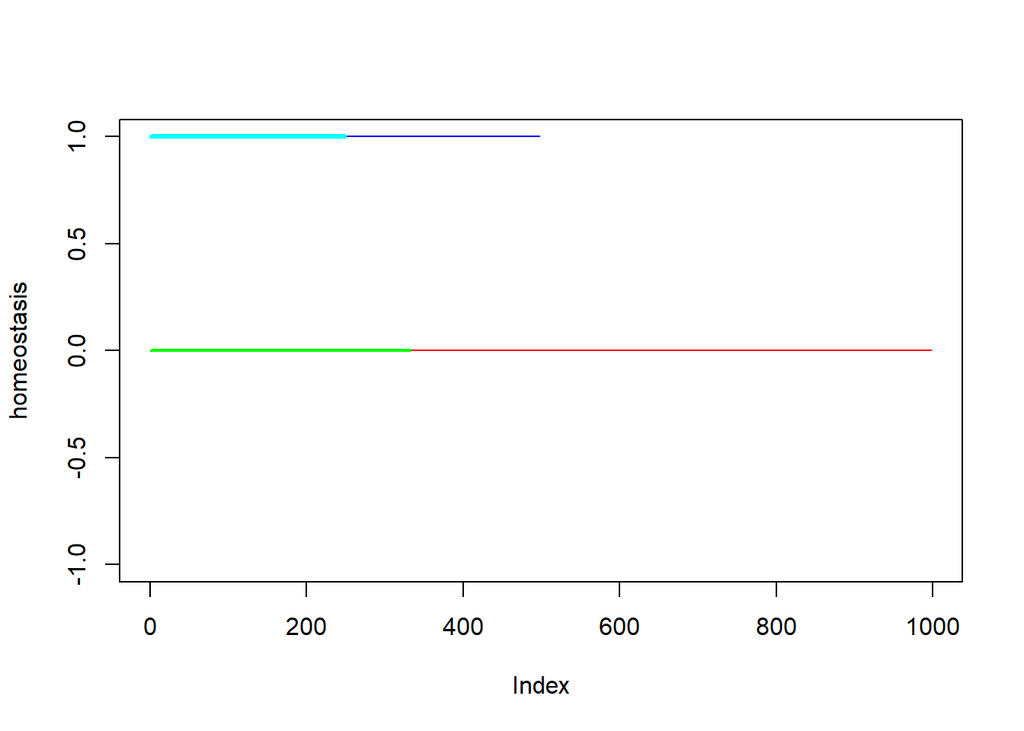

```r
plot(tmp.hmsts.ar1$homestasis, col='red', type='l', ylab = 'homeostasis')
lines(tmp.hmsts.ar2$homestasis, col='blue',lwd=1)
lines(tmp.hmsts.ar3$homestasis, col='green',lwd=2)
lines(tmp.hmsts.ar4$homestasis, col='cyan',lwd=3)
```

A system with n=4 variables and a seasonality of frequency 4

|  | x1 | x2 | x3 | x4 |
| --- | --- | --- | --- | --- |
| t_1 | 1 | 1 | 0 | 0 |
| t_2 | 0 | 0 | 1 | 1 |
| t_3 | 1 | 0 | 0 | 0 |
| t_4 | 0 | 0 | 1 | 1 |
| t_5 | 1 | 1 | 0 | 0 |
| t_6 | 0 | 0 | 1 | 1 |
| t_7 | 1 | 0 | 0 | 0 |
| t_8 | 0 | 0 | 1 | 1 |
| t_9 | 1 | 1 | 0 | 0 |
| t_10 | 0 | 0 | 1 | 1 |

```r
source(homeo.lib)

tmp.hmsts.ar1 <- homeostasis.dataframe.binary(tmp.df,b_order = 1)
tmp.hmsts.ar2 <- homeostasis.dataframe.binary(tmp.df,b_order = 2)
tmp.hmsts.ar3 <- homeostasis.dataframe.binary(tmp.df,b_order = 3)
tmp.hmsts.ar4 <- homeostasis.dataframe.binary(tmp.df,b_order = 4)

tmp_res <- cbind(tmp.hmsts.ar1$H_average,tmp.hmsts.ar2$H_average,
                 tmp.hmsts.ar3$H_average,tmp.hmsts.ar4$H_average)
colnames(tmp_res) <- c('b_or=1','b_or=2','b_or=3','b_or=4')

kable(tmp_res, caption = 'Analyzing different block sizes', align='l')
```

Analyzing different block sizes

| b_or=1 | b_or=2 | b_or=3 | b_or=4 |
| --- | --- | --- | --- |
| 0.125 | 0.75 | 0 | 1 |

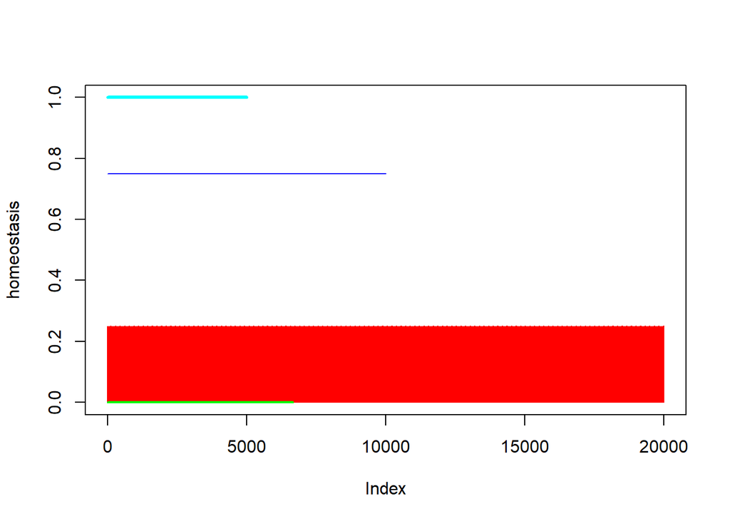

```r
plot(tmp.hmsts.ar1$homestasis, col='red', type='l', ylab = 'homeostasis', ylim=c(0,1))
lines(tmp.hmsts.ar2$homestasis, col='blue',lwd=1)
lines(tmp.hmsts.ar3$homestasis, col='green',lwd=2)
lines(tmp.hmsts.ar4$homestasis, col='cyan',lwd=3)
```

### 4.1.1 Discrete systems

In the case where variables are continuous i.e., $X_1,\ldots,X_N\in\mathbb{R}^N$, `homeostasis.dataframe.binary` can be employed to estimate $H$, however we require to discretize measurements from $\mathbb{R}\ \rightarrow\ \mathbb{Z}$. If we do not discretize these, system states ($A_t=[X_1^t,\ldots,X_N^t]$ and $A_{t+1}=[X_1^{t+1},\ldots,X_N^{t+1}]$) will be trivially different by small perturbations. Therefore, first we discretize each variable following one discretization methods. Then, the binary homeostasis function is calculated using a $b_{order} = 1$.

In this example, we analyze a sine time series corrupted by uniform noise using two different discretization methods (i.e., equidistant discretization and Piecewise Aggregation Approximation -PAA-).

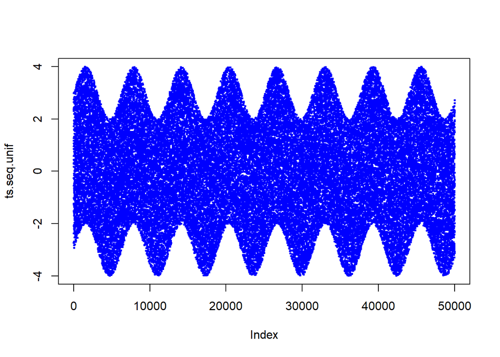

Equidistant discretization

In this method, for each variable the $x_{min}$ and $x_{max}$ values are obtained. The range defined by $[x_{min},x_{max}]$ is divided into $z$ equidistant intervals. Each interval is named using a lowercase letter, and measurements are replaced by its corresponding interval symbol.

```r
z <- 10
ts.disc <- ts.seq.unif %>% cut(breaks=z,labels=letters[1:z])
tmp.df  <- data.frame(replicate(2,ts.disc))

tmp.hmsts     <- homeostasis.dataframe.binary(tmp_df = tmp.df)
print(paste('H=',tmp.hmsts$H_average))
```

```
## [1] "H= 0.127282545650913"
```

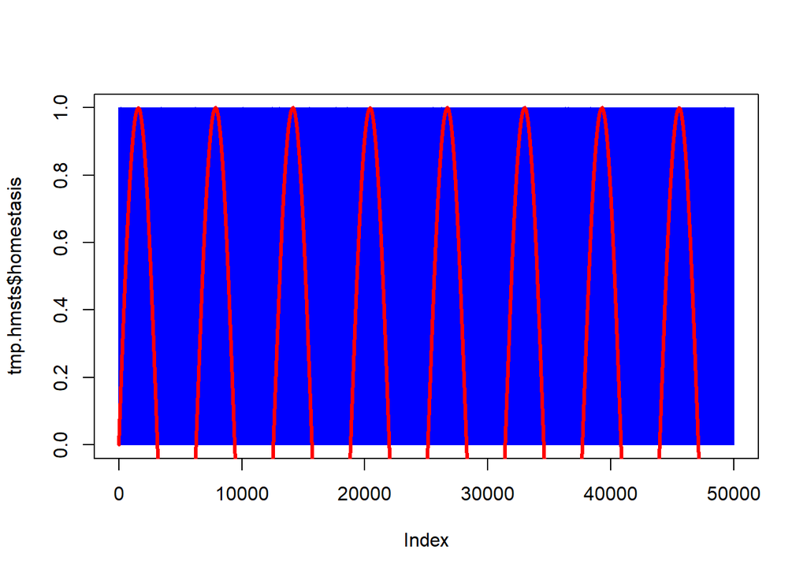

```r
plot(tmp.hmsts$homestasis, col='blue', type='l')
lines(sin.ts, col='red',lwd=3)
```

Piecewise Aggregate Approximation (PAA) discretization

PAA is an approach of average dimensional reduction. For each variable, PAA divides the time sequence in $w$ equi-size segments, and take the mean value of each segment as representation. It requires first to *standardize* the time series. Then, the mean value of data falling within the segment will be calculated and the mean value will replace whole segment as the new representation.

```r
library(TSclust)
set.seed(12349)
w <- 1000 #amount of equal-sized frames to divide the series, parameters for PAA

#standardize
y   <- (sin.ts - mean(sin.ts)) /sd(sin.ts)

#generate PAA reductions
paay<- PAA(y, w)
#generate PAA expansion
ts.disc<- rep(paay,each=length(y)/length(paay))

tmp.df <- data.frame(replicate(2,ts.disc))

tmp.hmsts     <- homeostasis.dataframe.binary(tmp.df)
print(paste('H=',tmp.hmsts$H_average))
```

```
## [1] "H= 0.980019200768031"
```

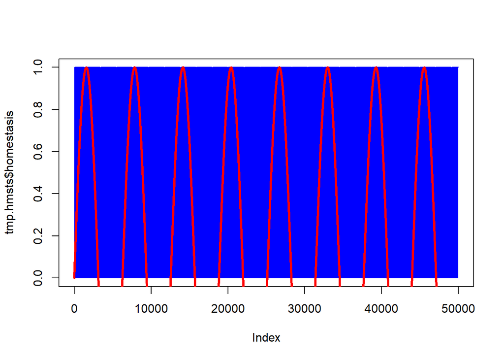

```r
plot(tmp.hmsts$homestasis, col='blue', type='l')
lines(sin.ts, col='red',lwd=3)
```

## 4.2 Continuous systems

### 4.2.1 Unit Circle in $\mathbb{R}$

Comparing the distance between two vectors, both starting at (1,0); one moves counterclockwise and the other moves clockwise.

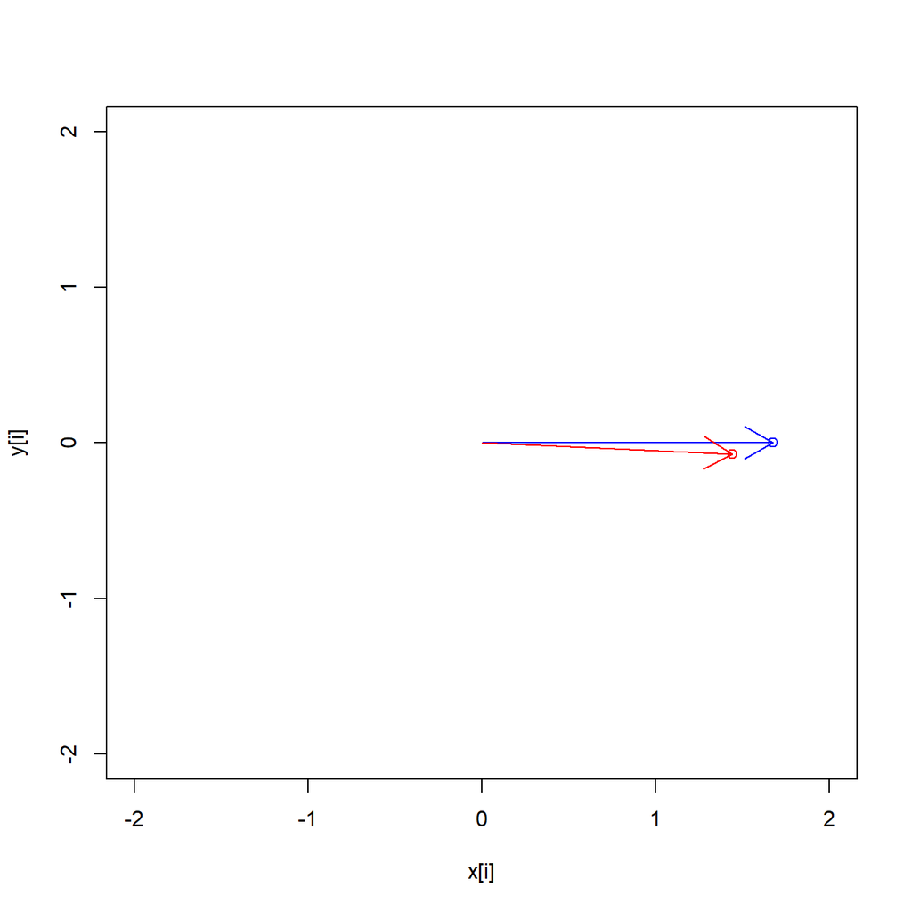

```r
phi   <- seq(0,2*pi,by=1/30)
r     <- runif(length(phi), min = 1, max = 2)
const <- 0
x <- (r*cos(phi))+const
y <- (r*sin(phi))+const

smpl_len <- length(x)

for(i in 1:(smpl_len-1))
{
  plot(x[i], y[i], col='blue',xlim=c(-2,2),ylim=c(-2,2))
  arrows(x0 = 0, y0 = 0,
         x1 = x[i], y1 = y[i], col = "blue")

  points(x[smpl_len-i],y[smpl_len-i], col='red')
  arrows(x0 = 0, y0 = 0,
         x1 = x[smpl_len-i], y1 = y[smpl_len-i], col = "red")
  }
```

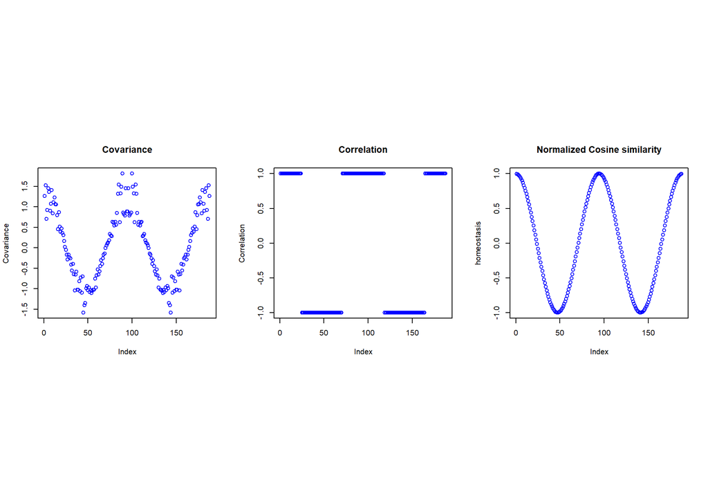

```r
smpl_len <- length(x)

res <- data.frame(bx_i = rep(0,times=smpl_len-1),
                  by_i = rep(0,times=smpl_len-1),
                  covv=rep(0,times=smpl_len-1),
                  corr=rep(0,times=smpl_len-1),
                  h=rep(0,times=smpl_len-1))

for(i in 1:(smpl_len-1))
{
  l_x <- c(x[i],y[i]) %>% matrix(ncol=1)
  l_y <- c(x[smpl_len-i],y[smpl_len-i]) %>% matrix(ncol=1)

  res$bx_i[i] <- x[i]
  res$by_i[i] <- y[i]

  res$covv[i] <- cov(l_x,l_y)
  res$corr[i] <- cor(l_x,l_y)
  res$h[i]    <- homeostasis.vector.continuous(l_x, l_y)
}

layout(matrix(c(1,2,3), nrow = 1, ncol = 3, byrow = TRUE),  respect=T)
plot(res$covv,col='blue', main="Covariance", ylab = 'Covariance')
plot(res$corr,col='blue', main="Correlation", ylab = 'Correlation')
plot(res$h,col='blue', main="Normalized Cosine similarity", ylab = expression(homeostasis))
```

### 4.2.2 Comparison in $\mathbb{R}^+$

Comparing the distance between two vectors, one starting at (1,0) and the other at (0,1); one moves counterclockwise and the other moves clockwise.

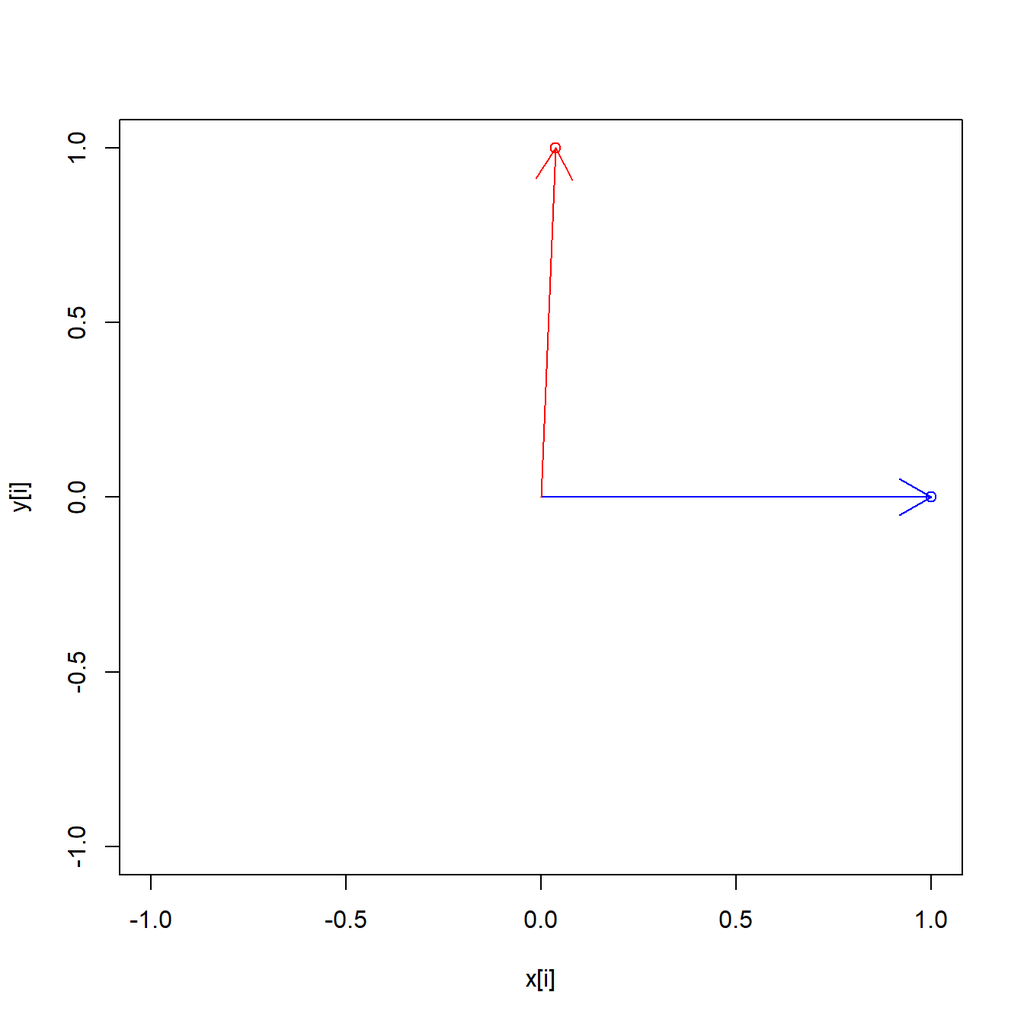

```r
r     <-1
phi   <- seq(0,0.5*pi,by=1/30)
const <- 0
x <- (r*cos(phi))+const
y <- (r*sin(phi))+const

smpl_len <- length(x)

for(i in 1:(smpl_len-1))
{
  plot(x[i], y[i], col='blue',xlim=c(-1,1),ylim=c(-1,1))
  arrows(x0 = 0, y0 = 0,
         x1 = x[i], y1 = y[i], col = "blue")

  points(x[smpl_len-i],y[smpl_len-i], col='red')
  arrows(x0 = 0, y0 = 0,
         x1 = x[smpl_len-i], y1 = y[smpl_len-i], col = "red")
  }
```

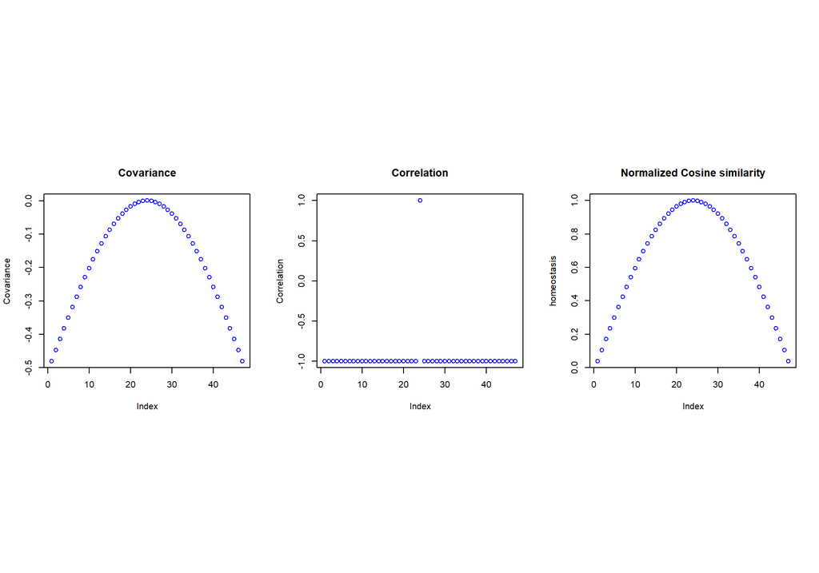

```r
smpl_len <- length(x)

res <- data.frame(bx_i = rep(0,times=smpl_len-1),
                  by_i = rep(0,times=smpl_len-1),
                  covv=rep(0,times=smpl_len-1),
                  corr=rep(0,times=smpl_len-1),
                  h=rep(0,times=smpl_len-1))

for(i in 1:(smpl_len-1))
{
  l_x <- c(x[i],y[i]) %>% matrix(ncol=1)
  l_y <- c(x[smpl_len-i],y[smpl_len-i]) %>% matrix(ncol=1)

  res$bx_i[i] <- x[i]
  res$by_i[i] <- y[i]

  res$covv[i] <- cov(l_x,l_y)
  res$corr[i] <- cor(l_x,l_y)
  res$h[i]    <- homeostasis.vector.continuous(l_x, l_y)
}

layout(matrix(c(1,2,3), nrow = 1, ncol = 3, byrow = TRUE),  respect=T)
plot(res$covv,col='blue', main="Covariance", ylab = 'Covariance')
plot(res$corr,col='blue', main="Correlation", ylab = 'Correlation')
plot(res$h,col='blue', main="Normalized Cosine similarity", ylab = expression(homeostasis))
```

### 4.2.3 Experimental data

Experimental data from [EEG Samples](https://www.kaggle.com/datasets/wanghaohan/confused-eeg?resource=download). It corresponds to EEG signal data from 10 college students while they watched MOOC video clips. Videos are extracted from online education videos that are assumed not to be confusing for college students, such as videos of the introduction of basic algebra or geometry. Other extracted videos are expected to confuse a typical college student if is not familiar with the video topics like Quantum Mechanics, and Stem Cell Research. Dataset is composed of 20 videos, 10 in each category. Each video was about 2 minutes long. Videos are two-minute clips chopped in the middle of a topic to make the videos more confusing.

The students wore a single-channel wireless MindSet that measured activity over the frontal lobe. The MindSet measures the voltage between an electrode resting on the forehead and two electrodes (one ground and one reference) each in contact with an ear. After each session, the student rated his/her confusion level on a scale of 1-7, where one corresponded to the least confusing and seven corresponded to the most confusing. These labels are further normalized into labels of whether the students are confused or not. This label is offered as self-labelled confusion in addition to our predefined label of confusion.

These data are collected from ten students, each watching ten videos. Therefore, it can be seen as only 100 data points for these 12000+ rows. If you look at this way, then each data point consists of 120+ rows, which is sampled every 0.5 seconds (so each data point is a one minute video). Signals with higher frequency are reported as the mean value during each 0.5 second.

Each video lasts roughly two-minute long, the first 30 seconds and last 30 seconds were removed, and only the EEG data during the middle 1 minute is collected.

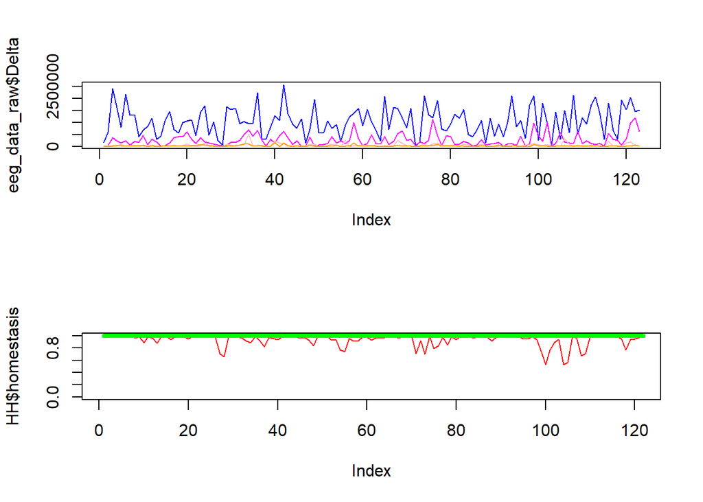

```r
source(homeo.lib)

tmp_data    <- read.csv(file=EEG_data.str,header = T)

eeg_data_raw<- filter(tmp_data,SubjectID== 8, VideoID == 5)
eeg_data    <- eeg_data_raw[,6:13]

block_order <- 1

HH <- homeostasis.dataframe.continuous(tmp_df = eeg_data, b_order = block_order)

par(mfrow=c(2,1))
plot(eeg_data_raw$Delta, type='l', col = 'blue')
lines(eeg_data_raw$Theta, col = 'magenta')
lines(eeg_data_raw$Alpha2,  col = 'pink')
lines(eeg_data_raw$Beta2,  col = 'orange')

plot(HH$homestasis, type='l', col='red',ylim=c(0,1))
lines(eeg_data_raw$user.definedlabeln[2:dim(eeg_data)[1]], col = 'green',lwd=4)
```

```r
print(paste('Homeostasis',HH$H_average))
```

```
## [1] "Homeostasis 0.930093375478957"
```

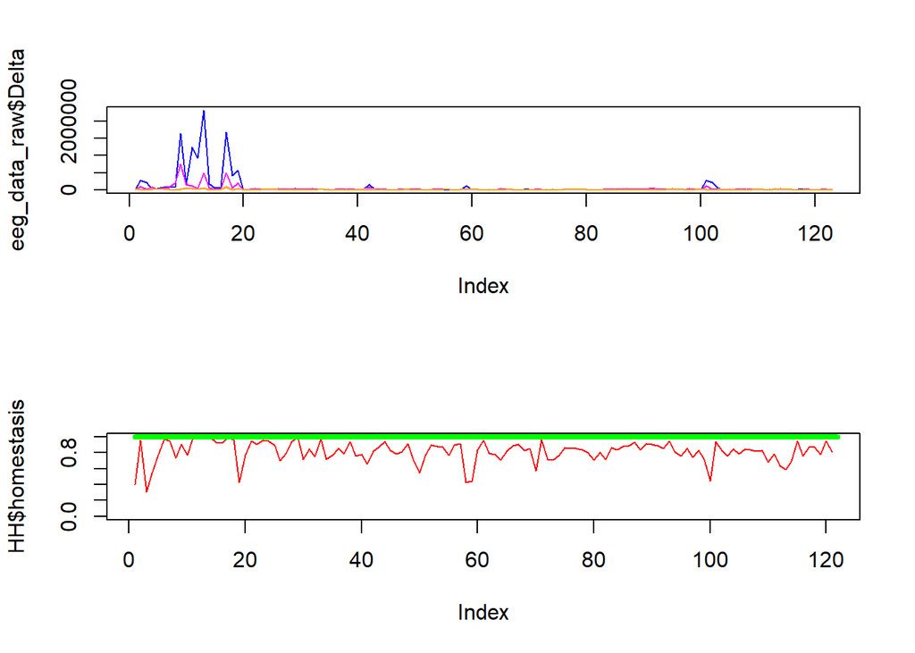

```r
eeg_data_raw<- filter(tmp_data,SubjectID== 2, VideoID == 5)
eeg_data    <- eeg_data_raw[,6:13]

block_order <- 1

HH <- homeostasis.dataframe.continuous(tmp_df = eeg_data, b_order = block_order)

par(mfrow=c(2,1))
plot(eeg_data_raw$Delta, type='l', col = 'blue')
lines(eeg_data_raw$Theta, col = 'magenta')
lines(eeg_data_raw$Alpha2,  col = 'pink')
lines(eeg_data_raw$Beta2,  col = 'orange')

plot(HH$homestasis, type='l', col='red',ylim=c(0,1))
lines(eeg_data_raw$user.definedlabeln[2:dim(eeg_data)[1]], col = 'green',lwd=4)
```

```r
print(paste('Homeostasis',HH$H_average))
```

```
## [1] "Homeostasis 0.810651745435339"
```

# 5 References

Fernández, N, C Maldonado, and C Gershenson. 2014. “Information Measures of Complexity, Emergence, Self-organization, Homeostasis, and Autopoiesis.” In *Guided Self-Organization: Inception*, edited by Mikhail Prokopenko, 9:19–51. Emergence, Complexity and Computation. Berlin Heidelberg: Springer. https://doi.org/10.1007/978-3-642-53734-9_2.

Gershenson, Carlos, and Nelson Fernández. 2012. “Complexity and information: Measuring emergence, self-organization, and homeostasis at multiple scales.” *Complexity* 18 (2): 29–44. https://doi.org/10.1002/cplx.21424.